# Consumer Preferences and Choice

Lecture 1

Div Bhagia

# Introduction

## Why Study Microeconomics?

- **Non-economists typically think of economics when it concerns the *macro* stuff** (unemployment, inflation, growth, recessions etc.)
- **However, the macro economy is made up of millions of *micro* decisions.**
  - **People:** what to buy, how much to work, how much to save
  - **Firms:** pricing, hiring, location, investment
  - **Government:** infrastructure, regulation, tax policy
- **Markets coordinate these decisions invisibly and *often* effectively**.
  - Gas is at the pump when you need it
  - Jobs exist for qualified workers
  - Products get delivered

## Why Study Microeconomics?

- **However, sometimes markets produce undesirable outcomes or fail.**
  - Each micro failure may seem small (one shortage, one person unemployed, one overpriced good)
  - But small failures add up to large macro consequences
- **In this course, we will study:**
  - How individuals and firms make decisions?
  - How markets coordinate these decisions?
  - When markets work efficiently and when they fail?
  - What interventions can help?

## Course Roadmap

### Competitive Markets

- Consumer choice (1-2)
- Firm production (3)
- Market equilibrium (4)
- Efficiency and welfare (5)

### Market Power

- Monopoly and oligopoly (6-7)
- Labor markets and monopsony (8)

### Market Failures

- Information asymmetries (9)
- Externalities and public goods (10)

### Uncertainty & Strategy

- Decisions under uncertainty (11)
- Game theory (12)

## Today’s Lecture

**Central question**: How do individuals make choices?

**Economic Approach to Choice**

- Individuals have **preferences** over outcomes
- These preferences are **rational** (satisfy certain axioms)
- We can represent preferences with a **utility function**
- Given constraints, individuals **maximize utility**

**Does everyone really “maximize utility”?**

- Maybe not consciously—but people behave “as if” they do
- The model predicts behavior relatively well
- Alternative: behavioral economics (we’ll discuss limitations)

# Preferences and Utility

## Preferences: Basic Setup

We consider a consumer choosing between bundles of goods.

- **Consumption bundle**: $(x, y)$ where $x, y \geq 0$
- **Preference relation**: $\succeq$ (weakly preferred to)
  - $A \succeq B$: Bundle $A$ is at least as good as bundle $B$
  - $A \succ B$: Bundle $A$ is strictly preferred to $B$
  - $A \sim B$: Consumer is indifferent between $A$ and $B$

**Key question**: What properties should preferences satisfy for them to be “rational”?

## Axioms of Rational Choice

### 1. Completeness

For any two bundles $A$ and $B$, the consumer can state which is preferred or that they are indifferent:
$$A \succeq B, \quad B \succeq A, \quad \text{or both (indifference)}$$

**Interpretation**: Consumers can always make comparisons. Rules out indecision.

### 2. Transitivity

If $A \succeq B$ and $B \succeq C$, then $A \succeq C$

**Interpretation**: Preferences are internally consistent. No cycles.

## Axioms of Rational Choice (cont.)

### 3. Continuity

Small changes in consumption bundles lead to small changes in preferences.

**Technical**: For any bundle $A$, the sets $\{B : B \succeq A\}$ and $\{B : A \succeq B\}$ are closed.

**Interpretation**: No sudden jumps. Preferences are “smooth.”

### 4. Non-satiation (Monotonicity)

More is better: If $A$ has at least as much of everything as $B$, and strictly more of at least one good, then $A \succ B$.

**Interpretation**: Consumers always prefer more to less (at least weakly).

## Axioms of Rational Choice (cont.)

### 5. Convexity

Averages are preferred to extremes. If $A \sim B$, then:
$$\lambda A + (1-\lambda)B \succeq A \text{ for } \lambda \in [0,1]$$

**Interpretation**: Consumers prefer balanced consumption bundles. Diminishing marginal rate of substitution.

## When Do Axioms Fail?

### Behavioral Economics Violations

- **Framing effects**: Preferences change based on how options are presented
- **Intransitivity**: Preference reversals in complex choices (Condorcet paradox)
- **Present bias**: Time-inconsistent preferences ($\beta\delta$ model)
- **Reference dependence**: Preferences depend on current endowment (loss aversion)
- **Bounded rationality**
  - Too many options → choice paralysis
  - Computational constraints
  - Limited attention

## From Preferences to Utility

**Key Theorem**: If preferences satisfy completeness, transitivity, continuity, and monotonicity, then there exists a continuous **utility function** $U(x,y)$ that represents them:
$$A \succeq B \iff U(A) \geq U(B)$$

**Interpretation**: We can assign numbers to bundles such that higher numbers = more preferred.

**Important**: Utility is **ordinal**, not **cardinal**

- Only the **ranking** matters, the magnitude of utility has no meaning.
- $U(A) = 10, U(B) = 5$ tells us $A \succ B$. It does NOT mean “$A$ is twice as good as $B$”

## Monotonic Transformations

- Since utility is ordinal, we can apply any **strictly increasing transformation** without changing preferences:
- If $U(x,y)$ represents preferences, so does $V(x,y) = f(U(x,y))$ for any strictly increasing $f$.
- **Examples**:
  - $U(x,y) = xy$ and $V(x,y) = \ln(xy)$ represent the same preferences
  - $U(x,y) = x^{0.5}y^{0.5}$ and $V(x,y) = xy$ represent the same preferences

**Why this matters**: We can transform utility functions to make calculations easier.

# Indifference Curves & MRS

## Indifference Curves

An **indifference curve** is the set of all bundles that give the same utility level:

$$IC(U_0) = \{(x,y) : U(x,y) = U_0\}$$

**Interpretation**: The consumer is indifferent between any two points on the same curve.

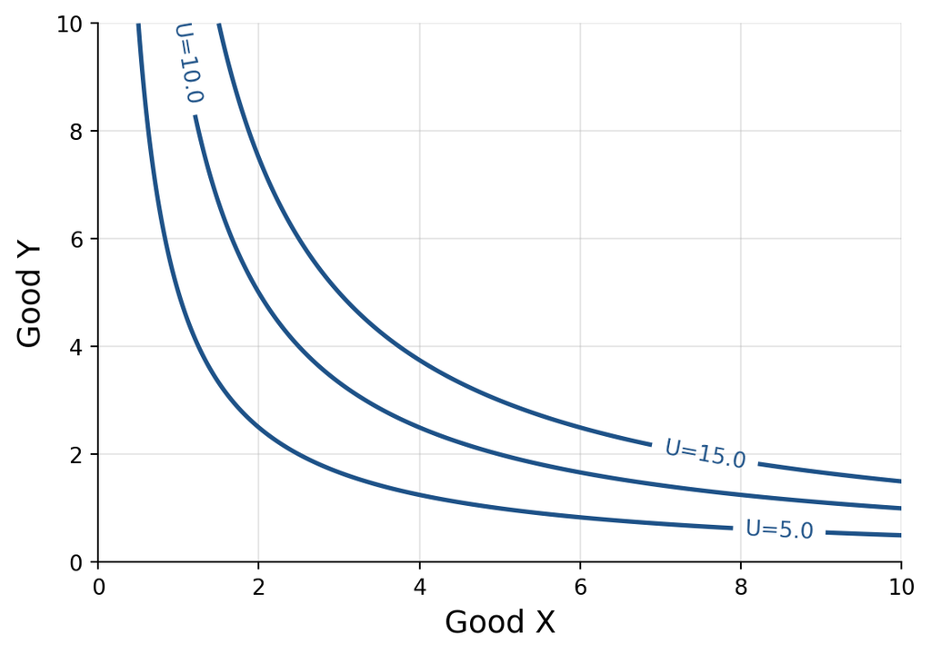

Indifference Curves for U(x,y) = xy

## Properties of Indifference Curves

**Under our axioms, indifference curves must be**:

1. **Downward sloping** (from non-satiation)
   - To keep utility constant, if $x$ increases, $y$ must decrease
2. **Do not cross** (from transitivity)
   - If they crossed, we’d have $A \sim B$ and $A \sim C$ but $B \not\sim C$
3. **Convex to the origin** (from convexity of preferences)
   - Averages preferred to extremes
   - Equivalently: diminishing marginal rate of substitution
4. **Higher curves represent higher utility** (from monotonicity)

## Marginal Rate of Substitution (MRS)

- The **marginal rate of substitution** is the rate at which the consumer is willing to trade good $Y$ for good $X$ while maintaining constant utility.
- **Geometrically**: MRS = -(slope of indifference curve)

$$MRS = -\frac{dy}{dx}\bigg|_{U=const}$$

- **Interpretation**: How many units of $Y$ are you willing to give up to get one more unit of $X$?
- **Example**: If MRS = 2, you’re willing to give up 2 units of $Y$ to get 1 more unit of $X$ (and remain indifferent).

## Deriving the MRS Formula

Along an indifference curve, utility is constant: $U(x,y) = \bar{U}$

Taking the total differential:
$$dU = \frac{\partial U}{\partial x}dx + \frac{\partial U}{\partial y}dy = 0$$

Rearranging:
$$\frac{\partial U}{\partial y}dy = -\frac{\partial U}{\partial x}dx \quad \rightarrow \quad \frac{dy}{dx} = -\frac{\partial U/\partial x}{\partial U/\partial y} = -\frac{MU_x}{MU_y}$$

Therefore:
$$\boxed{MRS = -\frac{dy}{dx} = \frac{MU_x}{MU_y}}$$

## Visualizing MRS

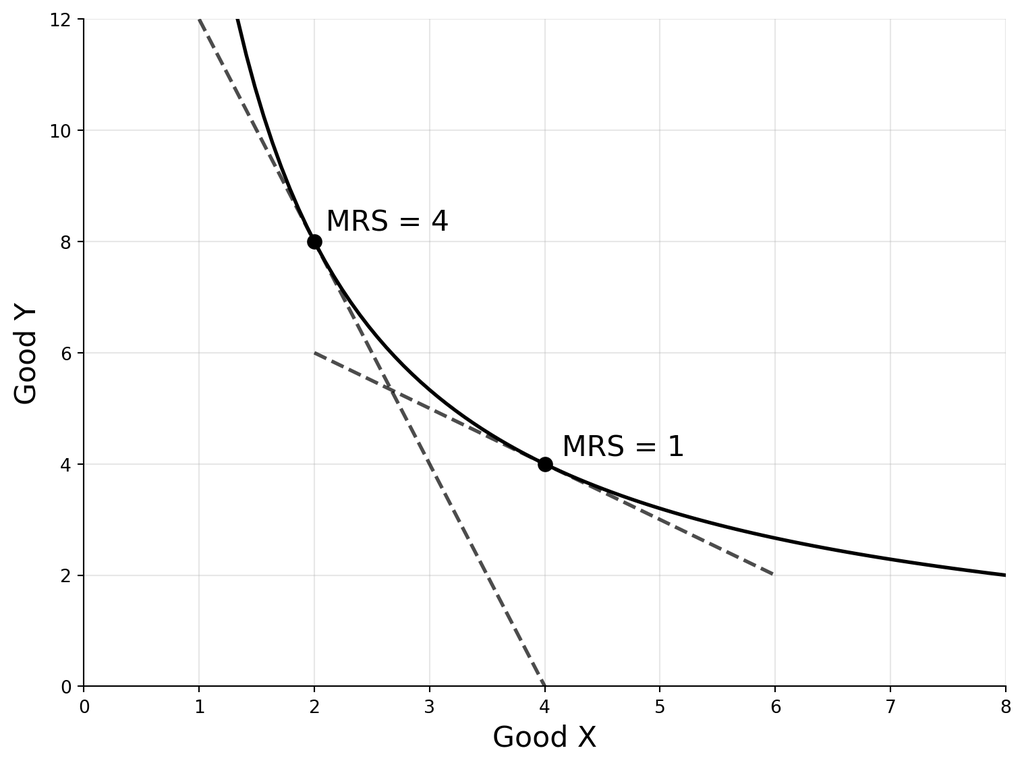

## Diminishing MRS

**Convexity assumption** → **Diminishing MRS**

As you consume more of good $X$ (moving right along an IC), the MRS decreases:

- When you have a lot of $Y$ and little $X$: High MRS (willing to give up a lot of $Y$ for more $X$)
- When you have a lot of $X$ and little $Y$: Low MRS (not willing to give up much $Y$ for more $X$)

**Economic intuition**: Scarcity increases value. The less you have of something, the more you value additional units.

## Try It Yourself: Calculate MRS

**Exercise**: Consider the utility function $U(x,y) = x^{0.3}y^{0.7}$

1. Find the marginal utilities $MU_x$ and $MU_y$
2. Calculate the MRS
3. Evaluate the MRS at the point $(x,y) = (10, 20)$
4. Interpret your answer: How many units of $y$ would the consumer give up for one more unit of $x$?

**Hint**: $MU_x = \frac{\partial U}{\partial x}$, and remember $MRS = \frac{MU_x}{MU_y}$

# Common Utility Functions

## Perfect Substitutes

Goods that can be substituted at a constant rate.

$$U(x,y) = ax + by$$

**Examples**:

- Different brands of the same product (e.g., Coke vs Pepsi for some consumers)
- Coffee from different cafes
- Generic vs brand-name drugs (if truly equivalent)

**Key features**:

- Indifference curves are **straight lines**
- MRS is **constant**: $MRS = a/b$
- Consumer willing to trade at fixed rate regardless of bundle

## Perfect Substitutes Graph

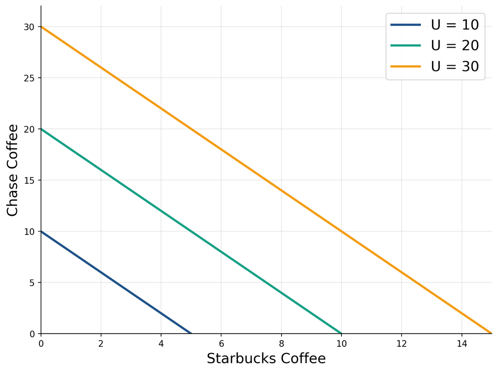

Perfect Substitutes: U = 2x + y

## Perfect Complements

Goods that must be consumed in fixed proportions.

$$U(x,y) = \min\{ax, by\}$$

**Examples**:

- Left and right shoes
- Coffee and cream (for some)
- Cars and tires (need 4 tires per car)
- Computers and monitors

**Key features**:

- Indifference curves are **L-shaped**
- Consumed in fixed ratio: $x/y = b/a$
- MRS is undefined (technically infinite or zero, depending on side)

## Perfect Complements Graph

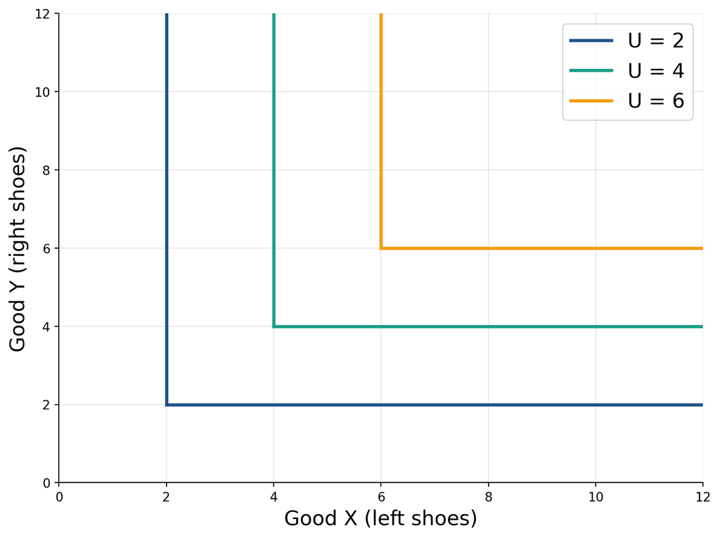

Perfect Complements: U = min{x, y}

## Cobb-Douglas Utility

The most widely used functional form in economics:

$$U(x,y) = x^{\alpha}y^{\beta}$$

Or equivalently (applying monotonic transformation):

$$U(x,y) = \alpha \ln x + \beta \ln y$$

**Key features**:

- Smooth, convex indifference curves
- Interior solutions (typically)
- Constant expenditure shares
- $MRS = \frac{\alpha}{\beta}\cdot\frac{y}{x}$

## Cobb-Douglas Graph

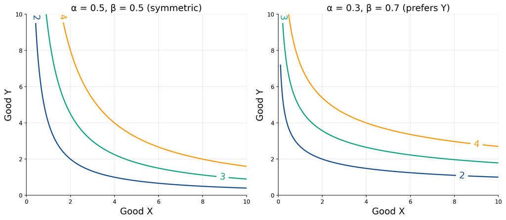

Cobb-Douglas Utility: $U = x^α y^β$

## Cobb-Douglas: MRS Calculation

For $U(x,y) = x^{\alpha}y^{\beta}$:

**Step 1**: Find marginal utilities
$$MU_x = \frac{\partial U}{\partial x} = \alpha x^{\alpha-1}y^{\beta}$$
$$MU_y = \frac{\partial U}{\partial y} = \beta x^{\alpha}y^{\beta-1}$$

**Step 2**: Calculate MRS
$$MRS = \frac{MU_x}{MU_y} = \frac{\alpha x^{\alpha-1}y^{\beta}}{\beta x^{\alpha}y^{\beta-1}} = \frac{\alpha}{\beta} \cdot \frac{y}{x}$$

MRS depends on the ratio $y/x$ and the preference parameters $\alpha/\beta$.

## CES Utility

**Constant Elasticity of Substitution (CES)** utility function:

$$U(x,y) = (ax^{\rho} + by^{\rho})^{1/\rho}, \quad \rho \leq 1, \rho \neq 0$$

**Elasticity of substitution**: $\sigma = \frac{1}{1-\rho}$

**Special cases**:

- $\rho \to -\infty$: Perfect complements ($\sigma = 0$)
- $\rho = 0$: Cobb-Douglas ($\sigma = 1$)
- $\rho = 1$: Perfect substitutes ($\sigma = \infty$)

**Flexibility**: CES nests all three cases mentioned.

# Budget Constraints

## The Budget Constraint

Consumers have limited income $I$ and face prices $p_x, p_y$ for goods:

$$p_x \cdot x + p_y \cdot y \leq I$$

**Budget line**: Set of bundles that cost exactly $I$

$$p_x \cdot x + p_y \cdot y = I$$

Rearranging for $y$:

$$y = \frac{I}{p_y} - \frac{p_x}{p_y}x$$

- **Intercept**: $I/p_y$ (max amount of $y$ if $x=0$)
- **Slope**: $-p_x/p_y$ (opportunity cost of $x$ in terms of $y$)

## Budget Constraint Graph

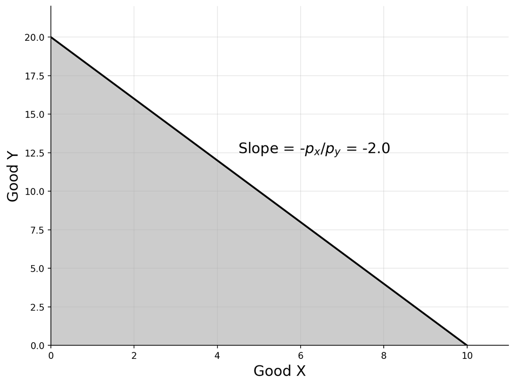

Budget Line with $I = 100, p_x = 10, p_y = 5$

## Changes in Income

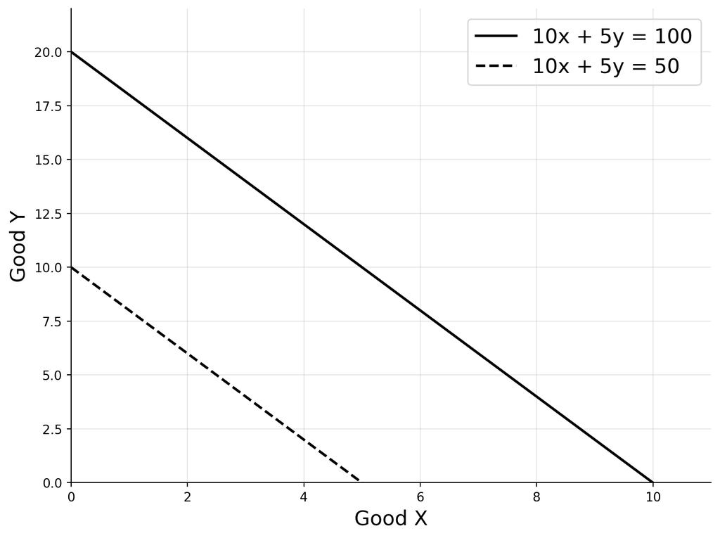

## Changes in Prices

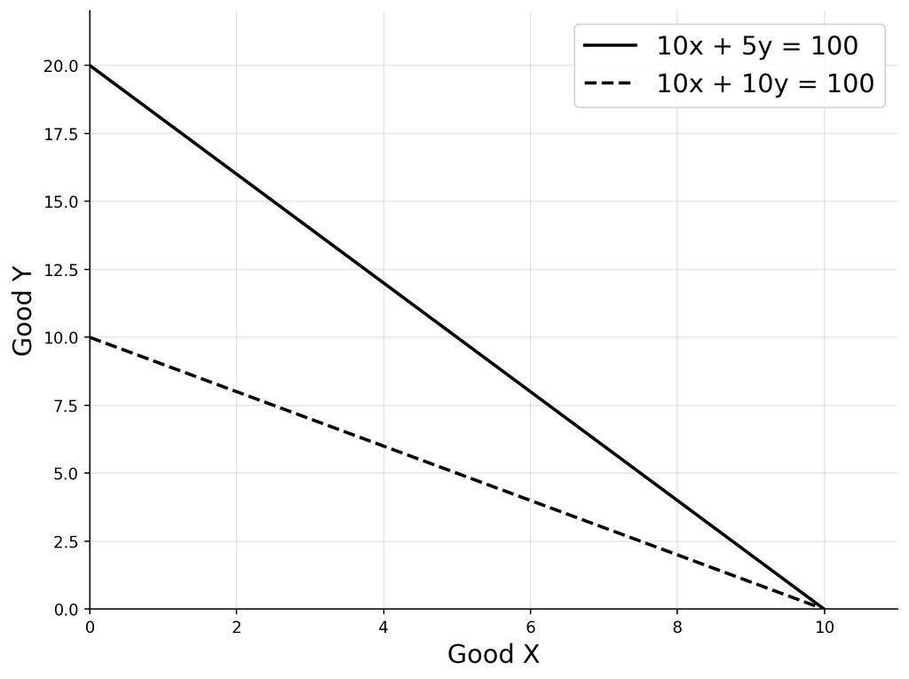

# Utility Maximization

## The Consumer’s Problem

The consumer chooses $(x,y)$ to:

$$\max_{x,y} \quad U(x,y)$$

subject to:

$$p_x x + p_y y = I$$
$$x \geq 0, \quad y \geq 0$$

**Goal**: Find the highest indifference curve that touches the budget line.

**Intuition**: Get as much utility as possible given your budget.

## Graphical Solution

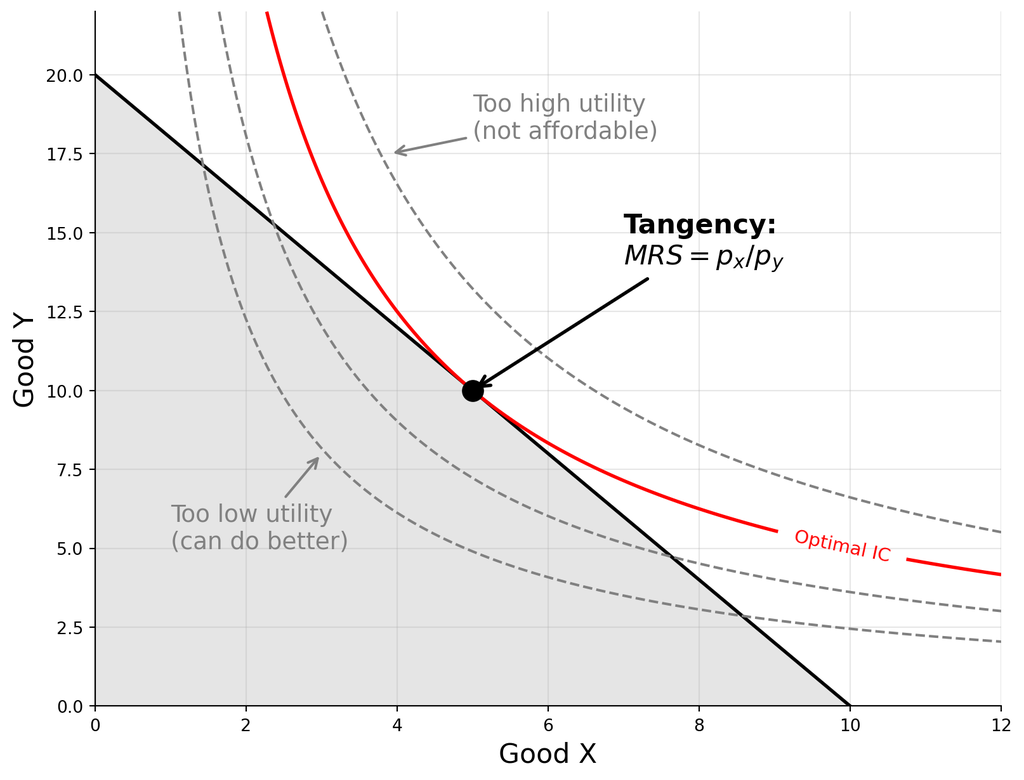

## Why Tangency is Optimal

**At the tangency point**: MRS = $p_x/p_y$

**Intuition**: Consumer’s subjective tradeoff (MRS) equals market tradeoff

- **MRS**: How much $Y$ you’re willing to give up for 1 unit of $X$
- **$p_x/p_y$**: How much $Y$ you must give up (in market) for 1 unit of $X$

**If MRS $>$ $p_x/p_y$**:

- You value $X$ more than market does
- Should buy more $X$, less $Y$

**If MRS $<$ $p_x/p_y$**:

- You value $X$ less than market does
- Should buy less $X$, more $Y$

## The Lagrangian Method

The consumer’s problem:
$$\max_{x,y} \quad U(x,y) \quad \text{subject to} \quad p_x x + p_y y = I$$

**Lagrangian**:
$$\mathcal{L}(x,y,\lambda) = U(x,y) + \lambda(I - p_x x - p_y y)$$

where $\lambda$ is the **Lagrange multiplier**.

**First-order conditions** (FOCs):

1. $\frac{\partial \mathcal{L}}{\partial x} = \frac{\partial U}{\partial x} - \lambda p_x = 0$
2. $\frac{\partial \mathcal{L}}{\partial y} = \frac{\partial U}{\partial y} - \lambda p_y = 0$
3. $\frac{\partial \mathcal{L}}{\partial \lambda} = I - p_x x - p_y y = 0$

## First-Order Conditions

From the first two FOCs:
$$MU_x = \lambda p_x \quad \text{and} \quad MU_y = \lambda p_y$$

Dividing these:
$$\frac{MU_x}{MU_y} = \frac{p_x}{p_y}$$

This is exactly the tangency condition: **MRS = price ratio**!

## Interpretation of λ

From FOCs: $\lambda = \frac{MU_x}{p_x} = \frac{MU_y}{p_y}$

**λ = marginal utility of income**

- How much utility increases if income increases by $1
- Measures the “value” of relaxing the budget constraint
- Important for welfare analysis

**Example**: If $\lambda = 0.5$:

- $1 more of income increases utility by 0.5 utils
- Equivalently: consumer willing to pay $2 for 1 more util

**Note**: λ decreases as income increases (diminishing marginal utility of income)

## Example: Cobb-Douglas Utility

**Setup**: $U(x,y) = x^{\alpha}y^{\beta}$, budget: $p_x x + p_y y = I$

**Step 1**: Form the Lagrangian
$$\mathcal{L} = x^{\alpha}y^{\beta} + \lambda(I - p_x x - p_y y)$$

**Step 2**: Take FOCs
$$\frac{\partial \mathcal{L}}{\partial x} = \alpha x^{\alpha-1}y^{\beta} - \lambda p_x = 0$$
$$\frac{\partial \mathcal{L}}{\partial y} = \beta x^{\alpha}y^{\beta-1} - \lambda p_y = 0$$
$$\frac{\partial \mathcal{L}}{\partial \lambda} = I - p_x x - p_y y = 0$$

## Example: Cobb-Douglas Utility (cont.)

**Step 3**: Combine first two FOCs
$$\frac{\alpha x^{\alpha-1}y^{\beta}}{\beta x^{\alpha}y^{\beta-1}} = \frac{p_x}{p_y}$$

Simplifying:
$$\frac{\alpha}{\beta} \cdot \frac{y}{x} = \frac{p_x}{p_y}$$

Solving for $y$:
$$y = \frac{\beta}{\alpha} \cdot \frac{p_x}{p_y} \cdot x$$

## Example: Cobb-Douglas Utility (cont.)

**Step 4**: Substitute into budget constraint
$$p_x x + p_y \cdot \frac{\beta}{\alpha} \cdot \frac{p_x}{p_y} \cdot x = I$$
$$p_x x + \frac{\beta}{\alpha} p_x x = I$$
$$p_x x \left(1 + \frac{\beta}{\alpha}\right) = I$$
$$p_x x \cdot \frac{\alpha + \beta}{\alpha} = I$$

## Example: Cobb-Douglas Utility (cont.)

**Step 5**: Solve for $x^*$:
$$x^* = \frac{\alpha I}{(\alpha + \beta)p_x}$$

Substitute back to get $y^*$:
$$y^* = \frac{\beta}{\alpha} \cdot \frac{p_x}{p_y} \cdot x^* = \frac{\beta}{\alpha} \cdot \frac{p_x}{p_y} \cdot \frac{\alpha I}{(\alpha + \beta)p_x} = \frac{\beta I}{(\alpha + \beta)p_y}$$

## Example: Cobb-Douglas Utility (cont.)

$$\boxed{x^* = \frac{\alpha I}{(\alpha + \beta)p_x}, \quad y^* = \frac{\beta I}{(\alpha + \beta)p_y}}$$

**Key results**:

- **Expenditure on X**: $p_x x^* = \frac{\alpha I}{\alpha + \beta}$
- **Expenditure on Y**: $p_y y^* = \frac{\beta I}{\alpha + \beta}$
- **Expenditure shares are constant**: $\frac{\alpha}{\alpha+\beta}$ and $\frac{\beta}{\alpha+\beta}$

## Constant Expenditure Shares

**Cobb-Douglas utility implies constant expenditure shares regardless of income or prices.**

Which of the following goods do you think have roughly constant expenditure shares in real life?

1. Food
2. Housing
3. Travel
4. Charitable giving

**Engel’s Law**: As income rises, the proportion spent on food decreases.

**How to model this?**

## Homogeneity of Demand Functions

**Homogeneity of degree zero**: If all prices and income are multiplied by the same factor $t > 0$:
$$x^*(tp_x, tp_y, tI) = x^*(p_x, p_y, I)$$

**Interpretation**: Demand depends only on **relative prices**, not absolute price level.

**Example**: If all prices and income double (inflation), consumption bundles don’t change.

**Why?** The budget constraint becomes:
$$tp_x \cdot x + tp_y \cdot y = tI$$
$$\Rightarrow p_x \cdot x + p_y \cdot y = I$$

## Indirect Utility Function

The **indirect utility function** $V(p_x, p_y, I)$ gives maximum achievable utility as a function of prices and income:

$$V(p_x, p_y, I) = U(x^*(p_x, p_y, I), y^*(p_x, p_y, I))$$

**Interpretation**: Maximum utility you can achieve given market conditions.

**Properties**:

1. Increasing in $I$: $\frac{\partial V}{\partial I} > 0$ (more money = higher utility)
2. Decreasing in prices: $\frac{\partial V}{\partial p_x} < 0, \frac{\partial V}{\partial p_y} < 0$ (higher prices = lower utility)
3. Homogeneous of degree zero: $V(tp_x, tp_y, tI) = V(p_x, p_y, I)$

## Cobb-Douglas Indirect Utility

For $U(x,y) = x^{\alpha}y^{\beta}$:

Substituting $x^* = \frac{\alpha I}{(\alpha+\beta)p_x}$ and $y^* = \frac{\beta I}{(\alpha+\beta)p_y}$:

$$V(p_x, p_y, I) = \left(\frac{\alpha I}{(\alpha+\beta)p_x}\right)^{\alpha} \left(\frac{\beta I}{(\alpha+\beta)p_y}\right)^{\beta}$$

Simplifying:
$$V(p_x, p_y, I) = \frac{I^{\alpha+\beta}}{p_x^{\alpha}p_y^{\beta}} \cdot \frac{\alpha^{\alpha}\beta^{\beta}}{(\alpha+\beta)^{\alpha+\beta}}$$

**Note**: $V$ increases with $I$ and decreases with $p_x$ and $p_y$ ✓

## Application: Gasoline Tax

- Indirect utility is the tool for **welfare analysis** of price/income changes
- **Example**: Government raises gas tax by $0.50/gallon. To compensate, gives everyone $200 cash transfer.
  - To answer if people are better or worse off, compare indirect utility before and after policy.
    - Before:
      $$V(p_{\text{gas}}, p_{\text{other}}, I)$$
    - After:
      $$V(p_{\text{gas}} + 0.50, p_{\text{other}}, I + 200)$$

## Application: Cash vs Food Stamps

**Policy question:** Give $200 cash or $200 food stamps?

**Setup:**

- Two goods: food (x) and other goods (y)
- Original income: I

**With cash:** Budget is $(p_x, p_y, I + 200)$

**With food stamps:** Can buy up to $200/p_x$ extra food, but must spend at least that on food

## Lump Sum Principle

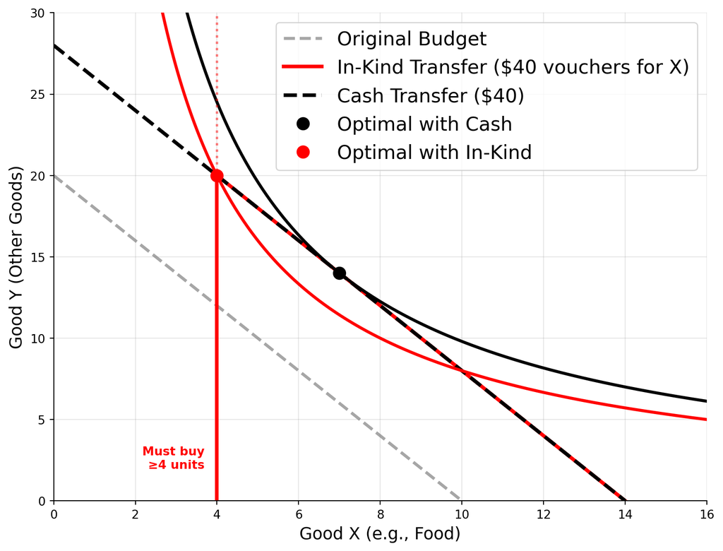

## Cash vs In-Kind Transfers

Lump sum principle implies:

- **Cash transfers are at least as good as in-kind transfers**, because they provide more flexibility
- If the in-kind transfer does not bind (i.e., the consumer would buy at least that much anyway), then cash and in-kind are equivalent
- If the in-kind transfer binds, cash is strictly better, as it allows the consumer to reach a higher indifference curve

**Then why do governments use in-kind transfers like SNAP, housing vouchers, etc.?**

Similar reasoning can be used to conclude that price subsidies are inferior to cash transfers.

## Summary

**What we covered**:

1. **Preferences**: Axioms of rational choice, utility representation
2. **Indifference curves**: Properties, MRS, diminishing MRS
3. **Common utility functions**: Perfect substitutes, perfect complements, Cobb-Douglas
4. **Budget constraints**: Slope = price ratio, shifts vs rotations
5. **Utility maximization**: Tangency condition (MRS = $p_x/p_y$), Lagrange method
6. **Applications**: Indirect utility, lump sum principle